# EDA On Pollution & Cancer

Jianing Hu

4/26/2022

# 5291 project EDA on Pollution + Cancer

```r
library(tidyverse)
library(dplyr)
```

## Import Data

```r
site <- read_csv("site.csv")
Filter_Pack_Concentrations_Weekly <- read_csv("Filter Pack Concentrations - Weekly.csv")
site_new<- site %>% select(SITE_ID,STATE,COUNTY,LATITUDE,LONGITUDE,ELEVATION)
data <- full_join(site_new,Filter_Pack_Concentrations_Weekly,by='SITE_ID') %>%
  select(-QA_CODE,-DATEON,-COMMENT_CODES,-UPDATE_DATE,-ELEVATION,-TYPE,-TEMP_SOURCE, -TNO3, -NHNO3, -WSO2, -NSO4, -WNO3, -VALID_HOURS, -STD2LOCAL_CF, -FLOW_VOLUME)
cancer_raw <- read_csv("cancer_raw.csv")
```

```
## * `` -> ...1
```

## Transform Data

```r
data$date <- as.Date(data$DATEOFF, "%m/%d/%Y")
data <- data %>% select(-DATEOFF)
data$year <- format(as.Date(data$date, "%F"), "%Y")
colnames(data)[10] <- "Totoal_NA"
data_year <- data %>%
  rename(state_abbr = STATE) %>%
  group_by(state_abbr, year) %>%
  summarise(avg_TSO4 = mean(TSO4,na.rm=TRUE),
            avg_TNH4 = mean(TNH4,na.rm=TRUE),
            avg_CA = mean(CA,na.rm=TRUE),
            avg_MG = mean(MG,na.rm=TRUE),
            avg_NA = mean(Totoal_NA,na.rm=TRUE),
            avg_K = mean(K,na.rm=TRUE),
            avg_CL = mean(CL,na.rm=TRUE),
            avg_SO2 = mean(TOTAL_SO2,na.rm=TRUE),
            avg_NO3 = mean(TOTAL_NO3,na.rm=TRUE)) %>%
  ungroup()
cancer_incidence <- cancer_raw %>%
  select(AREA, AGE_ADJUSTED_RATE, COUNT, EVENT_TYPE, POPULATION, RACE, SEX, SITE, YEAR, Code) %>%
  filter(SITE == 'Lung and Bronchus', EVENT_TYPE == 'Incidence', YEAR != '2014-2018') %>%
  mutate(COUNT = as.integer(COUNT)) %>%
  pivot_wider(names_from = EVENT_TYPE, values_from = COUNT) %>%
  mutate(incidence_rate = Incidence/POPULATION) %>%
  rename(state=AREA, state_abbr=Code,year=YEAR,population=POPULATION)

cancer_mortality <- cancer_raw %>%
  select(AREA, AGE_ADJUSTED_RATE, COUNT, EVENT_TYPE, POPULATION, RACE, SEX, SITE, YEAR, Code) %>%
  filter(SITE == 'Lung and Bronchus', EVENT_TYPE == 'Mortality', YEAR != '2014-2018') %>%
  mutate(COUNT = as.integer(COUNT)) %>%
  pivot_wider(names_from = EVENT_TYPE, values_from = COUNT) %>%
  mutate(mortality_rate = Mortality/POPULATION) %>%
  rename(state=AREA, state_abbr=Code,year=YEAR,population=POPULATION)
```

## Missing Value in Cancer (Incidence / Mortality)

```r
library(gt)
cancer_incidence_na <- cancer_incidence %>%
  filter(SEX != 'Male and Female') %>%
  # Treat a state, same race w/ all years as a group
  group_by(state, RACE) %>%
  summarise(na_rate = round(sum(is.na(Incidence))/length(state), 2))
cancer_incidence_na %>%
  filter(na_rate == 0) %>%
  group_by(RACE) %>%
  tally() %>%
  rename(group_without_na = n) %>%
  inner_join(cancer_incidence_na %>% group_by(RACE) %>% tally() %>%
               rename(total_group = n), by = "RACE") %>%
  gt() %>%
  tab_header(
    title = md("Missing Incidence Values For Race (groups)"),
    subtitle = md("Treat a state and same race w/ all years as a group"))
```

Missing Incidence Values For Race (groups)

Treat a state and same race w/ all years as a group

| RACE | group_without_na | total_group |
| --- | --- | --- |
| All Races | 51 | 51 |
| American Indian/Alaska Native | 3 | 51 |
| Asian/Pacific Islander | 10 | 51 |
| Black | 34 | 51 |
| Hispanic | 14 | 51 |
| White | 51 | 51 |

```r
cancer_mortality_na <- cancer_mortality %>%
  filter(SEX != 'Male and Female') %>%
  # Treat a state, same race w/ all years as a group
  group_by(state, RACE) %>%
  summarise(na_rate = round(sum(is.na(Mortality))/length(state), 2))
cancer_mortality_na %>%
  filter(na_rate == 0) %>%
  group_by(RACE) %>%
  tally() %>%
  rename(group_without_na = n) %>%
  inner_join(cancer_mortality_na %>% group_by(RACE) %>% tally() %>%
               rename(total_group = n), by = "RACE") %>%
  gt() %>%
  tab_header(
    title = md("Missing Mortality Values For Race (groups)"),
    subtitle = md("Treat a state and same race w/ all years as a group"))
```

Missing Mortality Values For Race (groups)

Treat a state and same race w/ all years as a group

| RACE | group_without_na | total_group |
| --- | --- | --- |
| All Races | 51 | 51 |
| American Indian/Alaska Native | 2 | 51 |
| Asian/Pacific Islander | 6 | 51 |
| Black | 31 | 51 |
| Hispanic | 9 | 51 |
| White | 51 | 51 |

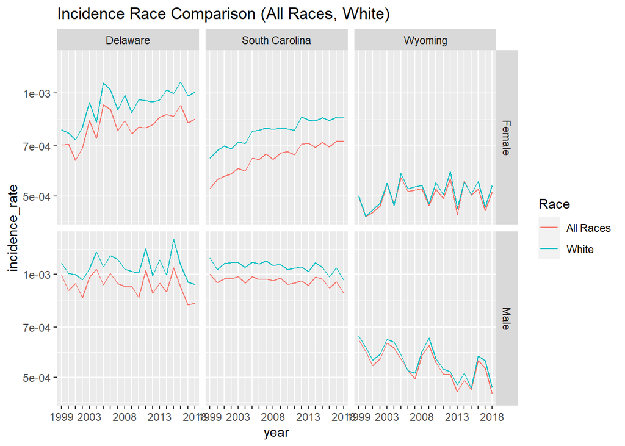

```r
sample_n_groups = function(grouped_df, size, replace = FALSE, weight=NULL) {
  grp_var <- grouped_df %>%
    groups %>%
    unlist %>%
    as.character
  random_grp <- grouped_df %>%
    summarise() %>%
    sample_n(size, replace, weight) %>%
    mutate(unique_id = 1:NROW(.))
  grouped_df %>%
    right_join(random_grp, by=grp_var) %>%
    group_by_(grp_var)
}

cancer_incidence %>%
  filter(SEX != 'Male and Female') %>%
  filter(RACE == "All Races" | RACE == "White") %>%
  group_by(state) %>%
  sample_n_groups(3) %>%
  group_by(SEX) %>%
  ggplot(., aes(x = year, y = incidence_rate, group = RACE, color = RACE)) +
  geom_line() +
  scale_y_log10() +
  facet_grid(SEX ~ state) +
  labs(title = "Incidence Race Comparison (All Races, White)", color = "Race") +
  scale_x_discrete(guide = guide_axis(check.overlap = TRUE))
```

```r
cancer_incidence <- cancer_incidence %>% filter(RACE == "All Races")
cancer_mortality <- cancer_mortality %>% filter(RACE == "All Races")
```

Here, we need to consider “sex” effects, so we filter out those data which belongs to “male and female” from our cancer data.

We were able to see definitively the number of missing mortality/incidence values in each category.

Since only “white” and “all races” categories don’t have missing incidence / mortality values, and all other categories contain numerous missing values. We prefer to use only the recordings belongs to “all races” but we need to verify whether other races have the same incidence / mortality trend with “all races”. Since the “white” category don’t have any missing values, we use this category as an instance to verify our preference.

## Test for Homogeneity of Male & Female

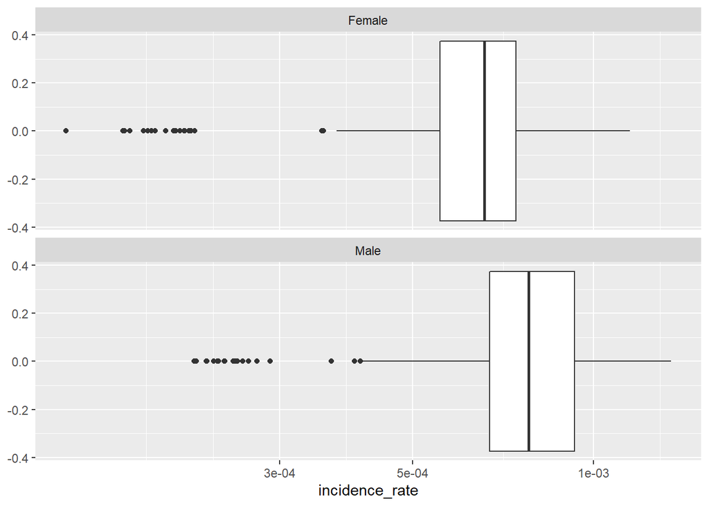

```r
cancer_incidence %>%
  filter(SEX != 'Male and Female') %>%
  ggplot(., aes(x = incidence_rate)) +
  geom_boxplot()+
  scale_x_log10() +
  facet_wrap(~SEX, ncol = 1)
```

```r
library(car)
# Test for same variance
cancer_incidence_sex <- cancer_incidence %>% filter(SEX != 'Male and Female')
leveneTest(cancer_incidence_sex$incidence_rate, cancer_incidence_sex$SEX)
```

```
## Levene's Test for Homogeneity of Variance (center = median)
##         Df F value    Pr(>F)
## group    1   71.99 < 2.2e-16 ***
##       2020
## ---
## Signif. codes:  0 '***' 0.001 '**' 0.01 '*' 0.05 '.' 0.1 ' ' 1
```

```r
# Test for same mean
t.test(incidence_rate ~ SEX,
  data = cancer_incidence_sex,
  var.equal = TRUE,
  alternative = "two.sided"
)
```

```
##
##  Two Sample t-test
##
## data:  incidence_rate by SEX
## t = -17.739, df = 2020, p-value < 2.2e-16
## alternative hypothesis: true difference in means between group Female and group Male is not equal to 0
## 95 percent confidence interval:
##  -0.0001569642 -0.0001257133
## sample estimates:
## mean in group Female   mean in group Male
##         0.0006508388         0.0007921775
```

```r
# Test for same distribution (Kolmogorov-Smirnov test)
male_incidence_rate <- (cancer_incidence_sex %>% filter(SEX == "Male"))$incidence_rate
female_incidence_rate <- (cancer_incidence_sex %>% filter(SEX == "Female"))$incidence_rate
ks.test(male_incidence_rate, female_incidence_rate)
```

```
##
##  Two-sample Kolmogorov-Smirnov test
##
## data:  male_incidence_rate and female_incidence_rate
## D = 0.35312, p-value < 2.2e-16
## alternative hypothesis: two-sided
```

```r
cancer_incidence <- cancer_incidence %>% filter(SEX != "Male and Female")
cancer_mortality <- cancer_mortality %>% filter(SEX != "Male and Female")
```

Here we test whether incidence_rate has significant difference between male & female groups.

## Combine Data

1. data type
2. convert to numeric

```r
pollution_cancer <-
  cancer_incidence %>%
  mutate(year = as.numeric(year)) %>%
  rename(aar_incidence = AGE_ADJUSTED_RATE) %>%
  inner_join(data_year %>% mutate(year = as.numeric(year)),
             by = c("state_abbr", "year")) %>%
  inner_join(cancer_mortality %>%
               select(year, state_abbr, AGE_ADJUSTED_RATE, mortality_rate, Mortality, SEX) %>%
               mutate(year = as.numeric(year)) %>%
               rename(aar_mortality = AGE_ADJUSTED_RATE),
             by = c("state_abbr", "year", "SEX"))
```

## Data Type

```r
str(pollution_cancer)
```

```
## tibble [1,514 x 22] (S3: tbl_df/tbl/data.frame)
##  $ state         : chr [1:1514] "Alabama" "Alabama" "Alabama" "Alabama" ...
##  $ aar_incidence : chr [1:1514] "46" "49.5" "51.1" "53.9" ...
##  $ population    : num [1:1514] 2293259 2302835 2309496 2314370 2324069 ...
##  $ RACE          : chr [1:1514] "All Races" "All Races" "All Races" "All Races" ...
##  $ SEX           : chr [1:1514] "Female" "Female" "Female" "Female" ...
##  $ SITE          : chr [1:1514] "Lung and Bronchus" "Lung and Bronchus" "Lung and Bronchus" "Lung and Bronchus" ...
##  $ year          : num [1:1514] 1999 2000 2001 2002 2003 ...
##  $ state_abbr    : chr [1:1514] "AL" "AL" "AL" "AL" ...
##  $ Incidence     : int [1:1514] 1194 1298 1352 1436 1378 1457 1535 1484 1591 1643 ...
##  $ incidence_rate: num [1:1514] 0.000521 0.000564 0.000585 0.00062 0.000593 ...
##  $ avg_TSO4      : num [1:1514] 5.75 6.18 4.99 4.21 4.9 ...
##  $ avg_TNH4      : num [1:1514] 2.38 2.59 2.17 1.75 2.03 ...
##  $ avg_CA        : num [1:1514] NaN 0.254 0.238 0.2 0.197 ...
##  $ avg_MG        : num [1:1514] NaN 0.0503 0.0502 0.046 0.0389 ...
##  $ avg_NA        : num [1:1514] NaN 0.193 0.208 0.21 0.119 ...
##  $ avg_K         : num [1:1514] NaN 0.121 0.102 0.102 0.092 ...
##  $ avg_CL        : num [1:1514] NaN NaN NaN NaN 0.0502 ...
##  $ avg_SO2       : num [1:1514] 5.77 6.03 5.11 4.75 4.94 ...
##  $ avg_NO3       : num [1:1514] 4 4.09 3.62 3.27 3.03 ...
##  $ aar_mortality : chr [1:1514] "37.8" "39.1" "39.7" "41.1" ...
##  $ mortality_rate: num [1:1514] 0.000433 0.000452 0.000459 0.000476 0.000498 ...
##  $ Mortality     : int [1:1514] 994 1041 1060 1102 1157 1167 1205 1135 1182 1153 ...
```

```r
pollution_cancer <-
  pollution_cancer %>% mutate_at(c('aar_incidence', 'aar_mortality'), as.numeric)
```

## Missing Values In Combined Data

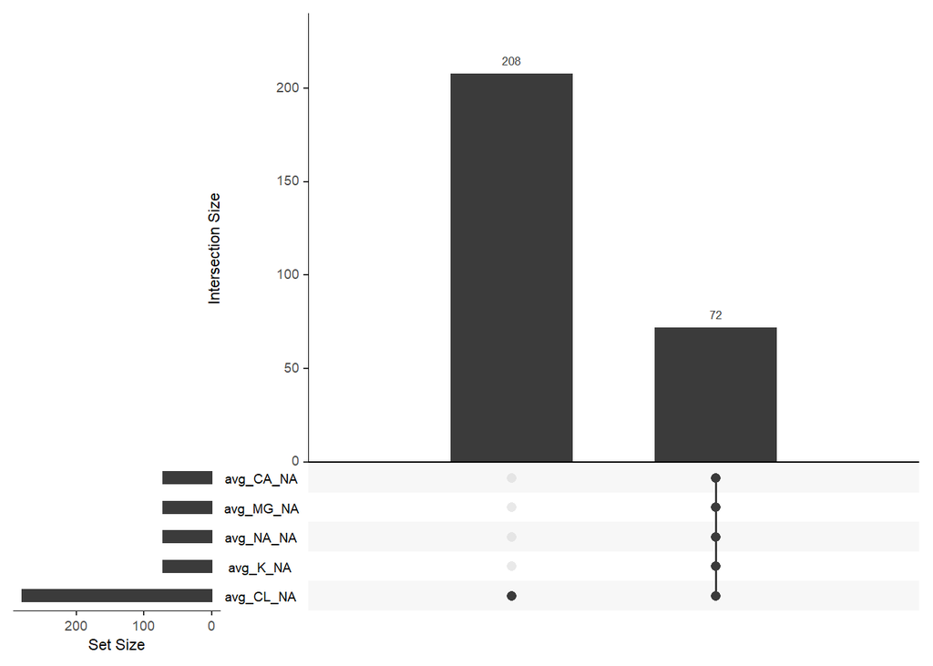

```r
# NAs
library(naniar)
gg_miss_upset(pollution_cancer)
```

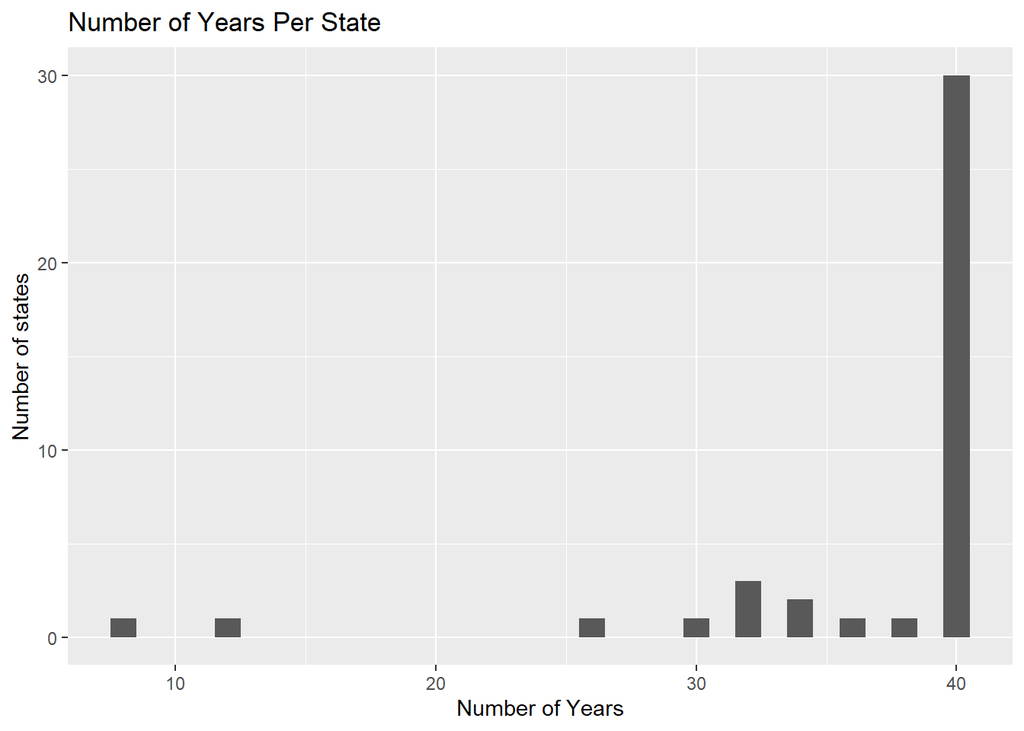

```r
# year
pollution_cancer %>%
  group_by(state) %>%
  tally() %>%
  ggplot(., aes(x = n)) +
  geom_histogram(binwidth = 1) +
  labs(title = 'Number of Years Per State') +
  scale_x_continuous('Number of Years') +
  scale_y_continuous('Number of states')
```

Also, some of the states lack of some years’ recordings

## Numerical Features’ Distribution (with Transformation)

```r
# First, summary the numerical features
pollution_cancer %>%
  keep(is.numeric) %>%
  select(-year, -population, -Incidence, -Mortality) %>%
  summary()
```

```
##  aar_incidence    incidence_rate         avg_TSO4         avg_TNH4
##  Min.   : 17.50   Min.   :0.0001322   Min.   :0.1936   Min.   :0.06568
##  1st Qu.: 54.00   1st Qu.:0.0006042   1st Qu.:0.8034   1st Qu.:0.30146
##  Median : 62.65   Median :0.0007080   Median :1.6523   Median :0.57600
##  Mean   : 67.46   Mean   :0.0007207   Mean   :1.9959   Mean   :0.72914
##  3rd Qu.: 79.75   3rd Qu.:0.0008233   3rd Qu.:2.9055   3rd Qu.:1.06918
##  Max.   :145.00   Max.   :0.0013455   Max.   :6.1843   Max.   :2.58621
##                                       NA's   :4        NA's   :4
##      avg_CA            avg_MG            avg_NA            avg_K
##  Min.   :0.02111   Min.   :0.00767   Min.   :0.01962   Min.   :0.01202
##  1st Qu.:0.13087   1st Qu.:0.02797   1st Qu.:0.06008   1st Qu.:0.04213
##  Median :0.20167   Median :0.03943   Median :0.09296   Median :0.06310
##  Mean   :0.25454   Mean   :0.04600   Mean   :0.16178   Mean   :0.06296
##  3rd Qu.:0.28213   3rd Qu.:0.05298   3rd Qu.:0.18939   3rd Qu.:0.08073
##  Max.   :2.06614   Max.   :0.24805   Max.   :1.82901   Max.   :0.16943
##  NA's   :72        NA's   :72        NA's   :72        NA's   :72
##      avg_CL           avg_SO2           avg_NO3        aar_mortality
##  Min.   :0.01325   Min.   : 0.1258   Min.   :0.09356   Min.   : 13.70
##  1st Qu.:0.03693   1st Qu.: 0.4743   1st Qu.:0.83302   1st Qu.: 37.80
##  Median :0.05591   Median : 0.8974   Median :1.43295   Median : 45.00
##  Mean   :0.14261   Mean   : 2.2053   Mean   :1.62733   Mean   : 50.53
##  3rd Qu.:0.08430   3rd Qu.: 2.7036   3rd Qu.:2.19873   3rd Qu.: 61.30
##  Max.   :5.83854   Max.   :40.7479   Max.   :5.09204   Max.   :120.90
##  NA's   :280       NA's   :4         NA's   :4
##  mortality_rate
##  Min.   :0.0001115
##  1st Qu.:0.0004335
##  Median :0.0005107
##  Mean   :0.0005301
##  3rd Qu.:0.0006156
##  Max.   :0.0010743
##
```

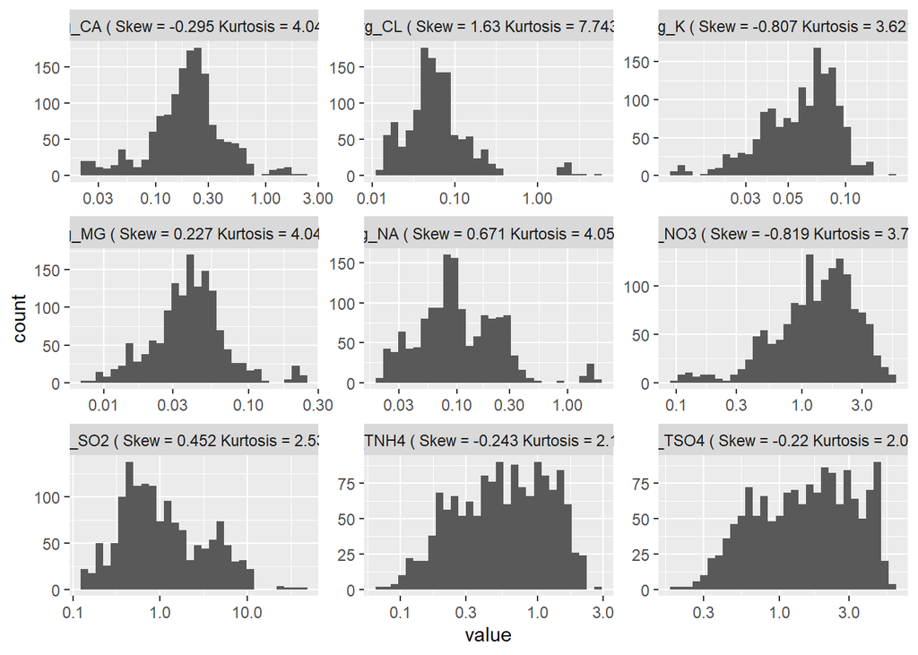

```r
library(moments)

sk_kur <- pollution_cancer %>%
  select(avg_CA, avg_K, avg_MG, avg_NA, avg_NO3, avg_SO2, avg_TSO4, avg_TNH4) %>%
  filter(!is.na(avg_CA)) %>%
  gather() %>%
  bind_rows(pollution_cancer %>% select(avg_CL) %>%
              filter(!is.na(avg_CL)) %>%
              mutate(key = "avg_CL") %>%
              rename(value = avg_CL)) %>%
  group_by(key) %>%
  summarise(Skew = round(skewness(log(value)), 3),
            Kurtosis = round(kurtosis(log(value)), 3)) %>%
  mutate(Skew=paste("Skew =", Skew),
         Kurtosis = paste("Kurtosis =", Kurtosis))

pollution_cancer %>%
  select(avg_CA, avg_K, avg_MG, avg_NA, avg_NO3, avg_SO2, avg_TSO4, avg_TNH4) %>%
  filter(!is.na(avg_CA)) %>%
  gather() %>%
  bind_rows(pollution_cancer %>% select(avg_CL) %>%
              filter(!is.na(avg_CL)) %>%
              mutate(key = "avg_CL") %>%
              rename(value = avg_CL)) %>%
  full_join(sk_kur, by = "key") %>%
  mutate(key = paste(key, "(", Skew, Kurtosis, ")")) %>%
  ggplot(aes(value)) +
  facet_wrap(~ key, scales = "free") +
  geom_histogram() +
  scale_x_log10()
```

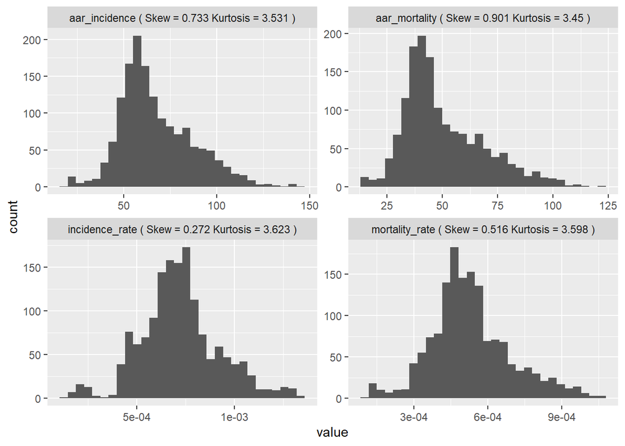

```r
sk_kur_cancer <- pollution_cancer %>%
  select(aar_incidence, incidence_rate, aar_mortality, mortality_rate) %>%
  gather() %>%
  group_by(key) %>%
  summarise(Skew = round(skewness(value), 3),
            Kurtosis = round(kurtosis(value), 3)) %>%
  mutate(Skew=paste("Skew =", Skew),
         Kurtosis = paste("Kurtosis =", Kurtosis))

pollution_cancer %>%
  select(aar_incidence, incidence_rate, aar_mortality, mortality_rate) %>%
  gather() %>%
  full_join(sk_kur_cancer, by = "key") %>%
  mutate(key = paste(key, "(", Skew, Kurtosis, ")")) %>%
  ggplot(aes(value)) +
  facet_wrap(~ key, scales = "free") +
  geom_histogram()
```

Here, all pollutants values are in log scale.

We can see all histograms are almost normal distributed.

We can also observe some outliers in some histograms, and only the distribution of avg_CL is highly skewed.

We next detect and treat the outliers.

## Outliers

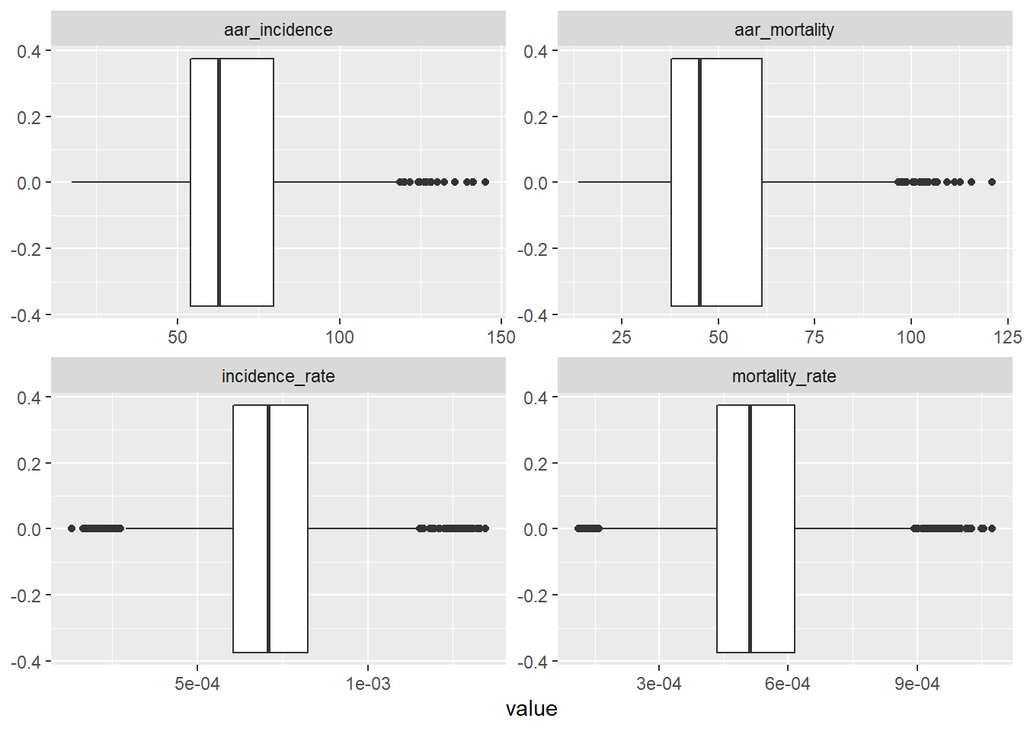

```r
pollution_cancer %>%
  select(aar_incidence, incidence_rate, aar_mortality, mortality_rate) %>%
  gather() %>%
  ggplot(aes(value)) +
  geom_boxplot() +
  facet_wrap(~ key, scales = "free", ncol = 2)
```

```r
library(outliers)

incidence_rate <- pollution_cancer$incidence_rate
grubbs.test(incidence_rate)
```

```
##
##  Grubbs test for one outlier
##
## data:  incidence_rate
## G = 3.11326, U = 0.99359, p-value = 1
## alternative hypothesis: highest value 0.00134546983488449 is an outlier
```

```r
grubbs.test(incidence_rate, opposite = T)
```

```
##
##  Grubbs test for one outlier
##
## data:  incidence_rate
## G = 2.93268, U = 0.99431, p-value = 1
## alternative hypothesis: lowest value 0.00013216327164821 is an outlier
```

```r
aar_incidence <- pollution_cancer$aar_incidence
grubbs.test(aar_incidence)
```

```
##
##  Grubbs test for one outlier
##
## data:  aar_incidence
## G = 3.90393, U = 0.98992, p-value = 0.06896
## alternative hypothesis: highest value 145 is an outlier
```

```r
grubbs.test(aar_incidence, opposite = T)
```

```
##
##  Grubbs test for one outlier
##
## data:  aar_incidence
## G = 2.51530, U = 0.99582, p-value = 1
## alternative hypothesis: lowest value 17.5 is an outlier
```

```r
mortality_rate <- pollution_cancer$mortality_rate
grubbs.test(mortality_rate)
```

```
##
##  Grubbs test for one outlier
##
## data:  mortality_rate
## G = 3.34635, U = 0.99259, p-value = 0.6073
## alternative hypothesis: highest value 0.00107425075561706 is an outlier
```

```r
grubbs.test(mortality_rate, opposite = T)
```

```
##
##  Grubbs test for one outlier
##
## data:  mortality_rate
## G = 2.57452, U = 0.99562, p-value = 1
## alternative hypothesis: lowest value 0.000111483503075013 is an outlier
```

```r
aar_mortality <- pollution_cancer$aar_mortality
grubbs.test(aar_mortality)
```

```
##
##  Grubbs test for one outlier
##
## data:  aar_mortality
## G = 3.87538, U = 0.99007, p-value = 0.07765
## alternative hypothesis: highest value 120.9 is an outlier
```

```r
grubbs.test(aar_mortality, opposite = T)
```

```
##
##  Grubbs test for one outlier
##
## data:  aar_mortality
## G = 2.02827, U = 0.99728, p-value = 1
## alternative hypothesis: lowest value 13.7 is an outlier
```

We use grubbs test to test whether the lowest and highest values in incidence_rate & mortality_rate & age adjusted rate are outliers.

It shows that there’s no outlier in all above variables.

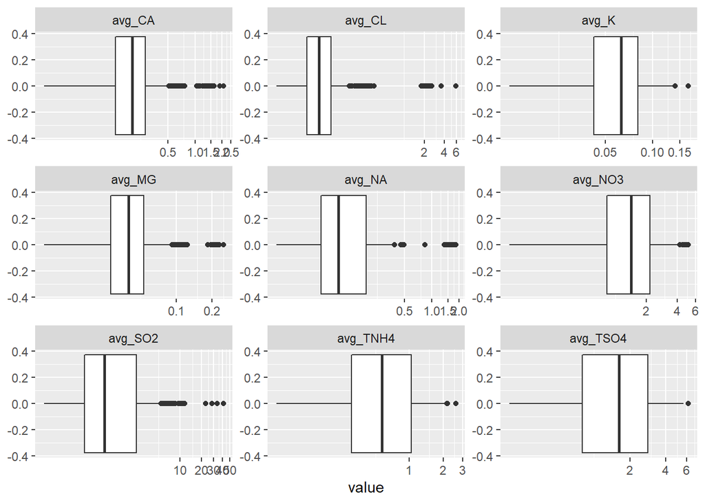

```r
pollution_cancer %>%
  select(avg_CA, avg_K, avg_MG, avg_NA, avg_NO3, avg_SO2, avg_TSO4, avg_TNH4) %>%
  filter(!is.na(avg_CA)) %>%
  gather() %>%
  bind_rows(pollution_cancer %>% select(avg_CL) %>%
              filter(!is.na(avg_CL)) %>%
              mutate(key = "avg_CL") %>%
              rename(value = avg_CL)) %>%
  ggplot(aes(value)) +
  geom_boxplot() +
  facet_wrap(~ key, scales = "free") +
  coord_trans(x="log10")
```

```r
pollution_cancer %>%
  select(avg_CA, state) %>%
  arrange(desc(avg_CA)) %>%
  distinct(., avg_CA, .keep_all = T) %>%
  head(6) %>%
  gt() %>%
  tab_header(title = md("CA Extremums"))
```

CA Extremums

| avg_CA | state |
| --- | --- |
| 2.066142 | Kansas |
| 1.903833 | Kansas |
| 1.642044 | Kansas |
| 1.627090 | Kansas |
| 1.623242 | Kansas |
| 1.557083 | Kansas |

```r
pollution_cancer %>%
  select(avg_CL, state) %>%
  arrange(desc(avg_CL)) %>%
  distinct(., avg_CL, .keep_all = T) %>%
  head(6) %>%
  gt() %>%
  tab_header(title = md("CL Extremums"))
```

CL Extremums

| avg_CL | state |
| --- | --- |
| 5.838538 | Florida |
| 3.564762 | Florida |
| 2.584313 | Florida |
| 2.560603 | Florida |
| 2.513312 | Florida |
| 2.417412 | Florida |

```r
pollution_cancer %>%
  select(avg_MG, state) %>%
  arrange(desc(avg_MG)) %>%
  distinct(., avg_MG, .keep_all = T) %>%
  head(6) %>%
  gt() %>%
  tab_header(title = md("MG Extremums"))
```

MG Extremums

| avg_MG | state |
| --- | --- |
| 0.2480461 | Florida |
| 0.2300109 | Florida |
| 0.2283020 | Florida |
| 0.2279263 | Florida |
| 0.2242566 | Florida |
| 0.2227977 | Florida |

```r
pollution_cancer %>%
  select(avg_NA, state) %>%
  arrange(desc(avg_NA)) %>%
  distinct(., avg_NA, .keep_all = T) %>%
  head(6) %>%
  gt() %>%
  tab_header(title = md("NA Extremums"))
```

NA Extremums

| avg_NA | state |
| --- | --- |
| 1.829008 | Florida |
| 1.741122 | Florida |
| 1.712747 | Florida |
| 1.683595 | Florida |
| 1.652234 | Florida |
| 1.639832 | Florida |

```r
pollution_cancer %>%
  select(avg_SO2, state) %>%
  arrange(desc(avg_SO2)) %>%
  distinct(., avg_SO2, .keep_all = T) %>%
  head(6) %>%
  gt() %>%
  tab_header(title = md("SO2 Extremums"))
```

SO2 Extremums

| avg_SO2 | state |
| --- | --- |
| 40.74788 | Hawaii |
| 33.66999 | Hawaii |
| 28.22507 | Hawaii |
| 23.15649 | Hawaii |
| 23.15046 | Hawaii |
| 22.29145 | Hawaii |

We can find some outliers in each pollutant data, also some extremums are included.

However, we cannot arbitrarily delete them or cap them with sample median / mean here.

Since we find out that the extremums of a pollutant values are always from the same state.

We cannot say this phenomenon is unreasonable.

## Multicollinearity

```r
library(GGally)
```

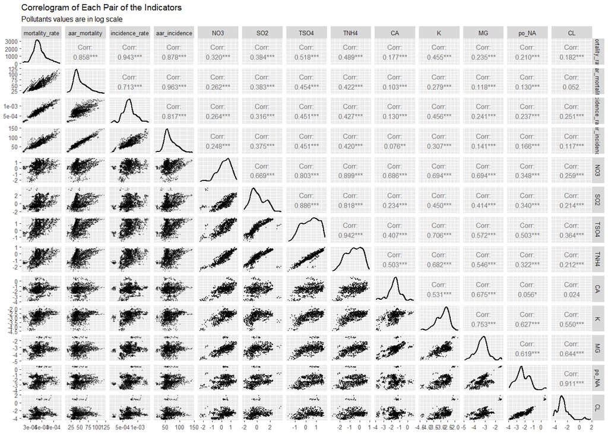

```r
pollution_cancer <- pollution_cancer %>%
  select(state, year, mortality_rate, aar_mortality, incidence_rate, aar_incidence,
         avg_NO3, avg_SO2, avg_TSO4, avg_TNH4, avg_CA, avg_K, avg_MG, avg_NA, avg_CL, SEX) %>%
  mutate(Female = ifelse(SEX == "Female", 1, 0)) %>%
  select(-SEX)

pollution_cancer %>%
  select(-state, -year, -Female) %>%
  mutate_at(vars(starts_with("avg")), funs(lg = log(.))) %>%
  select(-avg_NO3, -avg_SO2, -avg_TSO4, -avg_TNH4, -avg_CA, -avg_K, -avg_MG, -avg_NA, -avg_CL)%>%
  rename(NO3 = avg_NO3_lg, SO2 = avg_SO2_lg, TSO4 = avg_TSO4_lg, TNH4 = avg_TNH4_lg,
         CA = avg_CA_lg, K = avg_K_lg, MG = avg_MG_lg, po_NA = avg_NA_lg, CL = avg_CL_lg) %>%
  ggpairs(., upper = list(continuous = wrap("cor", size = 2)),
          lower = list(continuous = wrap("points", alpha = 0.3, size= 0.1)))+
  ggtitle("Correlogram of Each Pair of the Indicators", subtitle = "Pollutants values are in log scale") +
  theme_grey(base_size = 6)
```

```r
pollution_cancer_lg <- pollution_cancer %>%
  mutate_at(vars(starts_with("avg")), funs(lg = log(.))) %>%
  select(-avg_NO3, -avg_SO2, -avg_TSO4, -avg_TNH4, -avg_CA, -avg_K, -avg_MG, -avg_NA, -avg_CL)
```

Attention needs to be paid to the multicollinearity between pollutants when doing analysis!

```r
write.csv(pollution_cancer, file="pollution_cancer.csv")
write.csv(pollution_cancer, file="pollution_cancer_lg.csv")
```

** NOTE:

1. Teflon filter is considered to be more “chemically resistant” and Nylon filter to be the most “extractable free” for HPLC or Dissolution Testing.
2. Age Adjusted Rates is a rate that controls for the effects of differences in population age distributions. They eliminate the bias of age in the makeup of the populations being compared, thereby providing a much more reliable rate for comparison purposes.